# Untitled

```r
library(tidyverse)
library(readr)
hpi_tidy <- read_csv("~/Stat4005_DataVis/Data/data/hpi-tidy.csv")
```

Exericse 1. Make a map of a variable of your choosing. In coord_map(), use projection = “mercator”, which is also the default (we will see in a later exercise that this probably is not the best choice).

```r
library(mapproj)
library(maps)
library(tidyverse)
world_df <- ggplot2::map_data("world")
world_df %>% nrow()
```

```
## [1] 99338
```

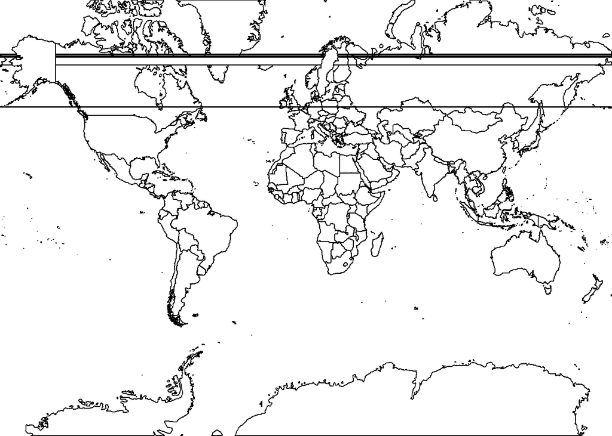

```r
ggplot(data = world_df,
            mapping = aes(x = long, y = lat,
                          group = group)) +
  geom_polygon(fill = "white", colour = "black") +
  coord_map(projection = "mercator") +
  theme(axis.text = element_blank()) +
  theme_void()
```

Unsure how to get the data from HPI tidy to work with the world data. Tried a join but unsure what to join by.

Exercise 2. You may notice that the United States does not get coloured in your map. Examine this issue further and fix the map so that the United States is coloured.

Exercise 3. You may have noticed that there are two horizontal stripes across your map. This is an issue that drove me nuts! Check out this submitted issue on ggplot2’s GitHub page for the reason for the error as well as a fix. Use it to fix your plot.

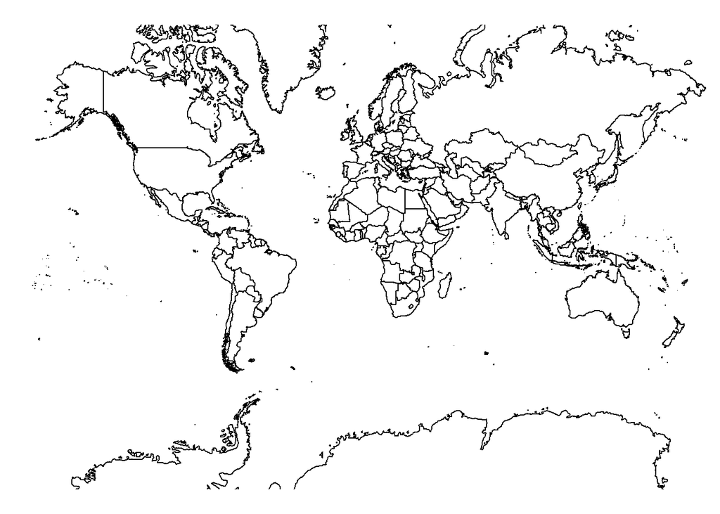

```r
ggplot(data = world_df,
            mapping = aes(x = long, y = lat,
                          group = group)) +
  geom_polygon(fill = "white", colour = "black") +
  coord_map(xlim=c(-180,180), projection = "mercator") +
  theme(axis.text = element_blank()) +
  theme_void()
```

Exercise 4. Read about Mercator projections in this blog post. What does this source say about the sizes of Greenland vs. Africa in a Mercator projection.

Greenland should fit into africa 14 times but on the mercator graph this is not the case

Exercise 5. Examine all of the different options for map projection with ?mapproject. Then, change the projection to “globular”. Change the projection again to “gilbert”. How does the relative size of Greenland to Africa change in the projections?

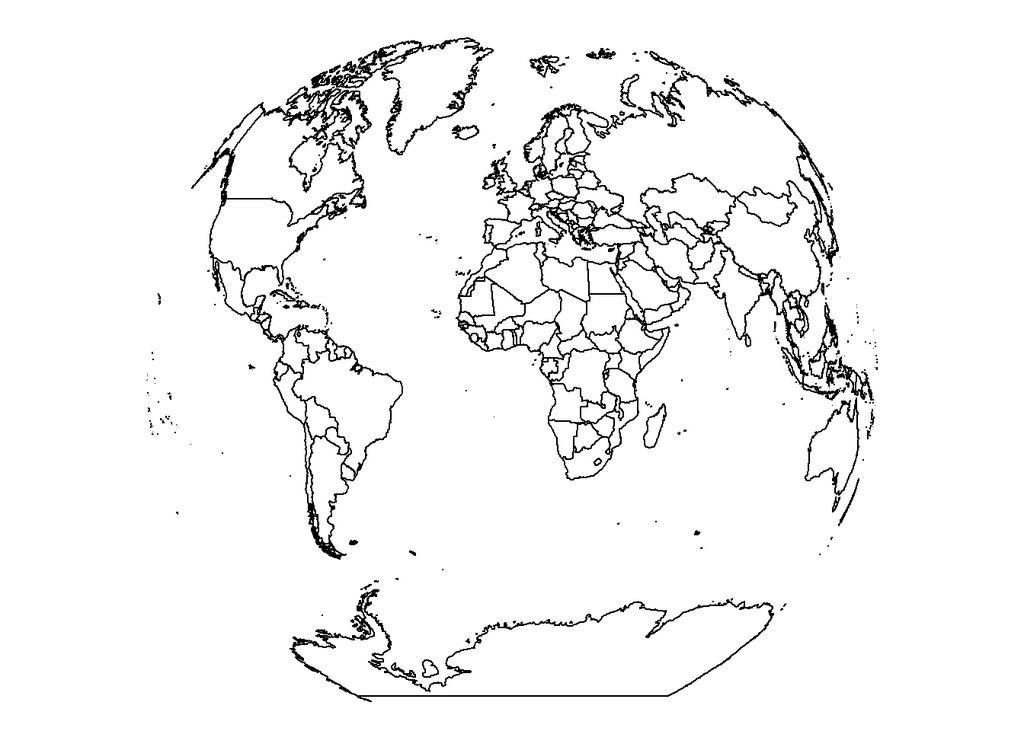

```r
ggplot(data = world_df,
            mapping = aes(x = long, y = lat,
                          group = group)) +
  geom_polygon(fill = "white", colour = "black") +
  coord_map(xlim=c(-180,180), projection = "gilbert") +
  theme(axis.text = element_blank()) +
  theme_void()
```

greenland becomes much smaller comparatively to africa.

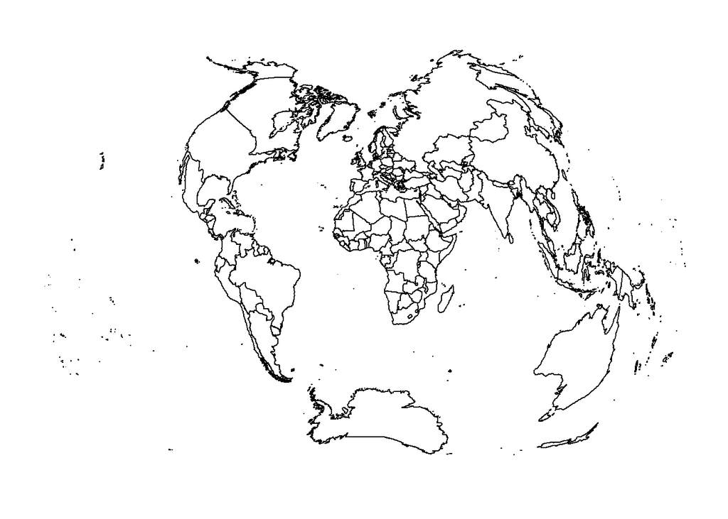

```r
ggplot(data = world_df,
            mapping = aes(x = long, y = lat,
                          group = group)) +
  geom_polygon(fill = "white", colour = "black") +
  coord_map(xlim=c(-180,180), projection = "globular") +
  theme(axis.text = element_blank()) +
  theme_void()
```

An even larger correction where greenland looks it could maybe fit in 14 times.